# Scraping Wikimedia PageView Draft

Aceri

Feb 22, 2020

## Synopsis

This is an [R Markdown](http://rmarkdown.rstudio.com) Notebook with some basic statistics and charts obtained from Wikimedia Statistics.

This is a very basic draft study to explore pageview data from dumps.wikimedia.org and performs some aggregations and plots out of them.

It is basically intended as a curiosity token in advance for the Wikimedia Analyst Position evaluation.

Note that this has been done in few hours and it is in Alpha stage.

Said that. Hope you find it interesting or helps show my interest in the position !.

## Configuration

I will be using knitr to publish the document on the web as a markdown document.

I use multiple libraries listed below. I have a created a number of non very polished functions (due very restricted time limits)

I include an ISO 3166-1 alpha 2 two letter country code from wikipedia itself and their ccTLD for the domain codes.

```r
  knitr::opts_chunk$set(echo = TRUE)

  library(sqldf)
  library(dplyr)
  library(httr)
  library(rvest)
  library(purrr)
  library(XML)
```

```r
  library(plotrix)
  library(ggplot2)
  library(tidyverse)
  library(cartography)
  library(sp)



  get_MonthDirDf<-function(month_WebDir)
  {
    # --------------------------------------------------------------------------------------------
    # Receives a string with a month with the format "2020-02" like dump.wikimedia URL format
    # Returns:  a dataframe with the monthly days and hours with equivalent gz file with pageviews
    # --------------------------------------------------------------------------------------------
    table<-readLines(paste("https://dumps.wikimedia.org/other/pageviews/2020/",month_WebDir,"/",sep=""))
    dtable<-as.data.frame(unlist(table))
    names(dtable)<-c("tags")
    pageview <- dtable[grepl('<a href="pageviews-',dtable$tags),]
    pageview<-as.data.frame(pageview)
    names(pageview)<-c("tags")
    foo <- data.frame(do.call('rbind', strsplit(as.character(pageview$tags),'-',fixed=TRUE)))[,c("X2","X3")]
    foo$X1<-data.frame(do.call('rbind', strsplit(as.character(foo$X3),'.',fixed=TRUE)))[,1]
    foo$X3<-NULL
    names(foo)<-c("days","hours")
    return(foo)
  }

  top_TotalViews_ByDomain <- function (dataframe,TopN)
  {
    # --------------------------------------------------------------------------------------------
    # Receives a Dataframe with the day / hour available .gz files from dump.wikimedia.org
    # Returns:  total number of days
    # --------------------------------------------------------------------------------------------
    TopN <- head(sqldf(paste('SELECT domain_code, SUM(count_views) as total_views FROM dataframe GROUP BY domain_code ORDER BY total_views DESC',sep="")),TopN)
    return(TopN)
  }

  top_TotalViews_ByPage <-function (dataframe,TopN)
  {
    # --------------------------------------------------------------------------------------------
    # Receives a Dataframe with the day / hour available .gz files from dump.wikimedia.org
    # Returns:  total number of days
    # --------------------------------------------------------------------------------------------
    TopN <- head(sqldf(paste('SELECT page_title, SUM(count_views) as total_views FROM dataframe GROUP BY page_title ORDER BY total_views DESC',sep="")),TopN)
    return(TopN)
  }

  top_TotalViews_ByDomain_PageTitleSearch <- function (dataframe, TopN, PageTitleSearch)
  {
    # --------------------------------------------------------------------------------------------
    # Receives a Dataframe with the day / hour available .gz files from dump.wikimedia.org
    # Returns:  total number of days
    # --------------------------------------------------------------------------------------------
    TopN <- head(sqldf(paste("SELECT domain_code, SUM(count_views) as total_views FROM dataframe WHERE UPPER(page_title) LIKE UPPER('",PageTitleSearch,"') GROUP BY domain_code ORDER BY total_views DESC",sep="")),TopN)
    return(TopN)
  }

  count_DaysThisMonth<-function(month_DirDf)
  {
    # --------------------------------------------------------------------------------------------
    # Receives a Dataframe with the day / hour available .gz files from dump.wikimedia.org
    # Returns:  total number of days
    # --------------------------------------------------------------------------------------------
    return(length(unique(month_DirDf$days)))
  }

  count_HoursThisDay<-function(month_DirDf,this_Day)
  {
    # --------------------------------------------------------------------------------------------
    # Receives a Dataframe with the day / hour available .gz files from dump.wikimedia.org
    #               and the specific day with format "20200221"
    # Returns:  total number of hourly files with data for a given day
    # --------------------------------------------------------------------------------------------
    return(as.numeric(sqldf(paste("SELECT COUNT(days) FROM month_DirDf WHERE days='",this_Day,"'",sep=""))))
  }



  circular_bar_plot<-function(twoColumn_df,title="",xtext="",ytext="",use_log_scale=0,startcolor="black",endcolor="orange",use_scale_width=0)
  {
    # --------------------------------------------------------------------------------------------
    # Receives a two column dataframe with labels and numbers
    # Displays a Circular bar plot
    # --------------------------------------------------------------------------------------------

    chart_Data = data.frame ( id = numeric(), angle = numeric() , hjust = numeric() , value = numeric(), label = character(), stringsAsFactors = FALSE)
    max_LengthAllowedInLabel=25
    min_LabelTextSize=5
    max_LabelTextSize=10
    number_of_bars=nrow(twoColumn_df)
    for ( i  in  1 : number_of_bars )
    {
        chart_Data [ i , 1 ] <- i
        chart_Data [ i , 2 ] <- 90 - 360 * (i - 0.5) / number_of_bars
        chart_Data [ i , 3 ] <- ifelse ( chart_Data [ i , 2 ] < -90 , 1 , 0 )
        chart_Data [ i , 2 ] <- ifelse ( chart_Data [ i , 2 ] < -90 , chart_Data [ i , 2 ] + 180 , chart_Data[ i , 2 ] )
        chart_Data [ i , 4 ] <- ifelse(use_log_scale==1,log(twoColumn_df[i,2]),twoColumn_df[i,2])
        chart_Data [ i , 5 ] <- gsub("_"," ",substr(twoColumn_df [ i , 1 ],1,max_LengthAllowedInLabel))
    }
    chart_Data<-as.data.frame(chart_Data)

    # Rescaling the label text size depending on the string length. With a @hardcoded maximum of 20 characters
    max_StringLengthInColumn <- max(nchar(chart_Data$label,type="chars"),na.rm=TRUE)

    label_TextScaling <- min(round(max_LengthAllowedInLabel/max_StringLengthInColumn*min_LabelTextSize,0),max_LabelTextSize)

    p <- ggplot( chart_Data, aes(x=as.factor(id),y=value,fill=value)) +
            geom_bar(stat="identity",width=ifelse(use_scale_width==1,0.9*(chart_Data$value/chart_Data$value[1])^3,0.9)) +
            scale_fill_continuous(low=startcolor, high=endcolor) +
            ylim(-chart_Data[1,4],chart_Data[1,4]*1.1) +
            coord_polar(start = 0) +
            geom_text(data=chart_Data, aes(x=id, y=value*1.01, label=label, hjust=hjust),
                    color="black", fontface="bold",alpha=0.6,
                    size=label_TextScaling, angle= chart_Data$angle,
                    inherit.aes = FALSE, nudge_y=6 ) +
            labs(x=xtext,y=ytext) + ggtitle(paste(title,ifelse(use_log_scale==1," (Log Scale)",""),sep=""))
    p
  }



  get_DayPageViews<-function(month_DirDf,this_Day,filter_string="",filter_out=0)
  {
    DEBUG=0
    # --------------------------------------------------------------------------------------------
    # Receives a Dataframe with the day / hour available .gz files from dump.wikimedia.org
    # Returns:  Dataframe with the pageviews for a given day
    #      "domain_code", "page_title", "count_views", "total_response_size", "date", "hour"
    # --------------------------------------------------------------------------------------------
    this_Year<-substr(this_Day,1,4)
    this_MonthDir<-paste(this_Year,"-",substr(this_Day,5,6),sep="")
    # Initializing and empty day_data dataframe in which we will collect all the data in the loop
    pageview_EntireDayDf <- data.frame(domain_code=character(),
                   page_title=character(),
                   count_view=integer(),
                   date=character(),
                   hour=character(),
                   stringsAsFactors=FALSE)
    count_Hours<-count_HoursThisDay(month_DirDf,this_Day)
    print(paste("Downloading data for day - ",this_Day,sep=""))
    if (DEBUG==1)    count_Hours=1
    for (k in 1:count_Hours)
    {
      this_Hour<-month_DirDf$hours[k]
      url <- paste("https://dumps.wikimedia.org/other/pageviews/",this_Year,"/",this_MonthDir,"/pageviews-",this_Day,"-",this_Hour,".gz",sep="")
      print(paste("       Downloading data for hour - ",this_Hour," [",k,"/",count_Hours,"] -> ",url,sep=""))
      tmp <- tempfile()
      download.file(url,tmp)
      new_Data <- read.csv(gzfile(tmp), sep=" ", header=FALSE,  stringsAsFactors=FALSE)
      names(new_Data)<-c("domain_code", "page_title", "count_views", "total_response_size")
      new_Data <- as.data.frame(new_Data)
      new_Data$date <- this_Day
      new_Data$hour <- this_Hour
      if (filter_string != "")
        {
          before_Rows=nrow(new_Data)
          new_Data<-filter_Domains(new_Data,filter_string,filter_out)
          after_Rows=nrow(new_Data)
          print(paste("Applied filter domain_code=",filter_string," ",ifelse(filter_out==0," - Inclusive "," - Exclusive ")," - Reduced from : ",before_Rows," to ",after_Rows," rows",sep=""))
        }
      # We bind dataframe to dataframe by row to collect them all
      pageview_EntireDayDf<-rbind(pageview_EntireDayDf,new_Data)
    }
    return(pageview_EntireDayDf)
  }

  filter_Domains<-function(pageview_Df,filter_string,filter_out=0)
  {
    # --------------------------------------------------------------------------------------------
    # Receives a Dataframe and a domain code filter string "en, es, fr". filter_out to 1 or 0
    # specifies if the domain codes should be the ones remaining or removed.
    # Returns:  Dataframe
    # --------------------------------------------------------------------------------------------

    toMatch <- unlist(strsplit(as.character(filter_string),',',fixed=TRUE))

    filtered_domain_codes<-unique (grep(paste(toMatch,collapse="|"), pageview_Df$domain_code, value=TRUE))
    if (filter_out==0) { ret <- pageview_Df[ pageview_Df$domain_code %in% filtered_domain_codes,]
    } else { ret <- pageview_Df[ !pageview_Df$domain_code %in% filtered_domain_codes,]}
    return(ret)
  }
```

## Data Processing

Using two loops I get a table with the different hours and gz filenames for a given month.

The script downloads each gz, uncompress them and adds them up to a dataframe

NOTE: I have hardcoded total_days=1 to avoid looping through all the month (time limnits)

```r
  rm(pageview_FullDf)
  month_DirDf<-get_MonthDirDf(month_WebDir="2020-02")
  count_Days  <- count_DaysThisMonth(month_DirDf)

  # !!!!!!!!!!!!!!!!!!!!!!!!!!!!!!!!!!!!!!!!!!!!!!!!!!!!!!!!!!!!
  # IMPORTANT !!!! HARDCODED TO AVOID DOWNLOADING ALL THE MONTH
  #
  # ------------------------------------------------------------
  count_Days=1
  load_from_disk=1
  # !!!!!!!!!!!!!!!!!!!!!!!!!!!!!!!!!!!!!!!!!!!!!!!!!!!!!!!!!!!!

  pageview_FullDf <- data.frame(domain_code=character(),
             page_title=character(),
             count_view=integer(),
             date=character(),
             hour=character(),
             stringsAsFactors=FALSE)

  days<-sqldf("select distinct(days) from month_DirDf")

  if (load_from_disk==1)
  {
    pageview_DayDf<-pageview_FullDf
    for (k in 1:count_Days)
    {
      this_Day<-days[k,1]
      load(file=paste("pageview_DayDf_",this_Day,".Rda",sep=""))
      pageview_DayDf<-filter_Domains(pageview_DayDf,filter_string="",filter_out=0)
      pageview_FullDf<-rbind(pageview_FullDf,pageview_DayDf)
      print(nrow(pageview_FullDf))
      rm(pageview_DayDf)
    }
  } else {
    for (j in 1:count_Days)
    {
      this_Day<-days[j,1]
      pageview_DayDf<-get_DayPageViews(month_DirDf,this_Day)
      save(pageview_DayDf,file=paste("pageview_DayDf_",this_Day,".Rda",sep=""))
      pageview_FullDf<-rbind(pageview_FullDf,pageview_DayDf)
      print(nrow(pageview_FullDf))
      rm(pageview_DayDf)
    }
  }
```

```
## [1] 72782942
```

## Data Exploration

Now that we have dowloaded the data we can do some initial exploration of the data

```r
  page_views_Top10ByDomain<-top_TotalViews_ByDomain(dataframe=pageview_FullDf,TopN=5)
  page_views_Top10ByDomain
```

```
##   domain_code total_views
## 1        en.m    80950907
## 2          en    43712293
## 3        de.m     9537886
## 4        es.m     9058867
## 5        fr.m     7553602
```

A basic pie chart would be:

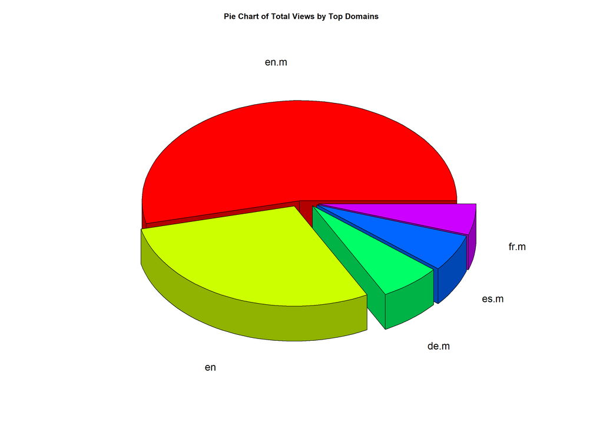

```r
  pie3D(page_views_Top10ByDomain$total_views,labels=page_views_Top10ByDomain$domain_code,explode=0.1, shade=0.7, theta=1,radius=0.9,main=paste("Pie Chart of Total Views by Top Domains",sep=""))
```

A relative weight representation for European Domain Codes

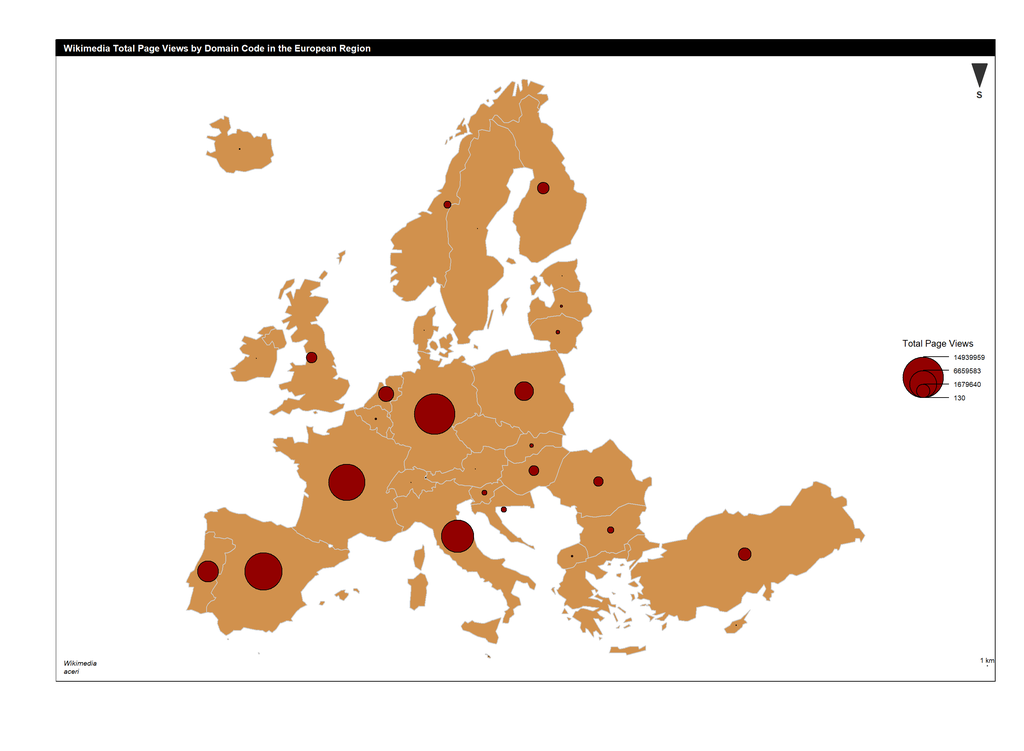

```r
# We will use the european domain codes from nuts2006
data(nuts2006)
european_codes<-paste(tolower(nuts0.df$id),collapse=",")


pageview_FullDf_copy<-pageview_FullDf
pageview_FullDf_copy$domain_code<-substr(pageview_FullDf_copy$domain_code,1,2)
total_views_by_domain<-sqldf('SELECT domain_code, SUM(count_views) as total_views FROM pageview_FullDf_copy GROUP BY domain_code ORDER BY total_views DESC')
rm(pageview_FullDf_copy)
european_domain_codes_Df<-filter_Domains(total_views_by_domain,filter_string=european_codes,filter_out=0)
names(european_domain_codes_Df)<-c("id","total_views")
european_domain_codes_Df$id<-toupper(european_domain_codes_Df$id)
european_domain_codes_Df$total_views<-as.double(european_domain_codes_Df$total_views)
missing_domains<-nuts0.df[!nuts0.df$id %in% european_domain_codes_Df$id,][1]
missing_domains$total_views<-0
european_domain_codes_Df<-rbind(missing_domains,european_domain_codes_Df)


plot(nuts0.spdf, col = "#D1914D", border = "grey80",  add = FALSE)

propSymbolsLayer(spdf = nuts0.spdf, df = european_domain_codes_Df,
    var = "total_views", symbols = "circle", col = "#920000",    legend.pos = "right", legend.title.txt = "Total Page Views",    legend.style = "c")
layoutLayer(title = "Wikimedia Total Page Views by Domain Code in the European Region",
    author = "aceri", sources = "Wikimedia",
    scale = TRUE, north=TRUE,south = TRUE)
```

Now the 10 top Pages Titles with highest number of pageviews:

```r
  page_views_Top10ByPage <-top_TotalViews_ByPage(dataframe=pageview_FullDf,TopN=10)
  page_views_Top10ByPage
```

```
##                      page_title total_views
## 1                     Main_Page     4818671
## 2                             -     1810093
## 3                Special:Search      893157
## 4          Wikipedia:Hauptseite      448940
## 5                   Kobe_Bryant      416814
## 6                   Coronavirus      410845
## 7                   Sofia_Kenin      313348
## 8             Wikipedia:Portada      289468
## 9  WikipÃ©dia:Accueil_principal      286782
## 10            Pagina_principale      254416
```

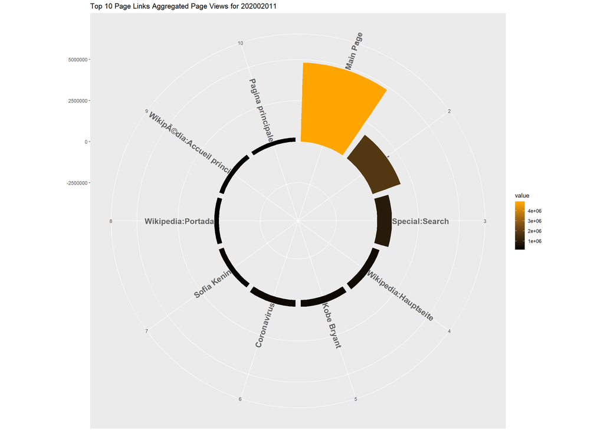

```r
circular_bar_plot(page_views_Top10ByPage,use_log=0,paste("Top 10 Page Links Aggregated Page Views for ",this_Day,sep="",1))
```

Can we see what countries pay more attention nowadays to link “CoronaVirus” ?